# ABC methods and visualisation

2025-04-13

## Load packages and functions

Load functions of ABC methods from `abc_rejection.r`, `abc_knn.r`, `abc_mcmc.r`, `abc_pmc.r` and `abc_llr.r`.

```r
library(ggplot2)
setwd("C:/Users/u2008181/mini_project")
source("abc_functions/abc_rejection.r")
source("abc_functions/abc_knn.r")
source("abc_functions/abc_mcmc.r")
source("abc_functions/abc_pmc.r")
source("abc_functions/abc_llr.r")
```

## ABC rejection

Consider model $Y \sim \mathcal{N}(0, 1)$, we observe 10 outcomes $\mathbf{y}_{obs} = (y_1, \dots, y_{10})$ and compute their mean as the observed summary statistics $s_{obs} = s(\mathbf{y}_{obs})$. To apply ABC methods, we generate data and summary statistics by this assumption:
$$\begin{align}
\mu &\sim U[-2, 2]\\
Y_i &\sim \mathcal{N}(\mu, 1), \ \text{for }i = 1, \dots, 10,\\
\end{align}$$
and the summary statistics is mean value between these 10 samples. We use this model to generate 100 summary statistics and in total 1000 data points.

```r
mu <- 0
# observation
s_obs <- mean(rnorm(10, mean=mu, sd=1))
# simulations
mu_vec <- runif(100, min=-2, max=2)
s_vec <- c()
for (i in 1:length(mu_vec)) {
  s_i <- mean(rnorm(10, mean=mu_vec[i]), sd=1)
  s_vec <- c(s_vec, s_i)
}
```

Then, use the simulated summary statistics to obtain weights for the $\mu$ values. We apply basic ABC rejection method here with uniform, epanechnikov and Gaussian kernels.

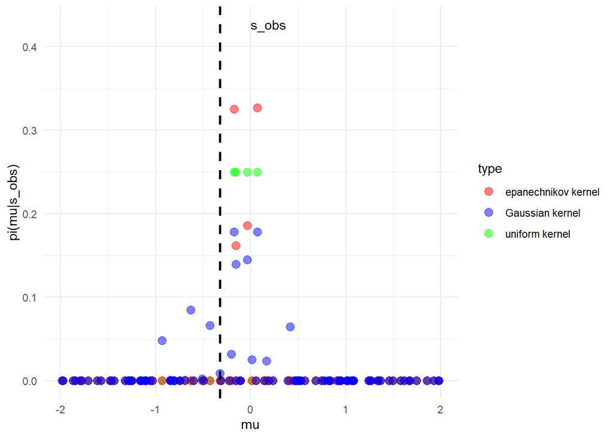

```r
weights1 <- abc_rejection(c(s_obs), matrix(mu_vec), matrix(s_vec),
                          tol=0.1, kernel = uniform_kernel)
weights2 <- abc_rejection(c(s_obs), matrix(mu_vec), matrix(s_vec),
                          tol=0.1, kernel = epanechnikov_kernel)
weights3 <- abc_rejection(c(s_obs), matrix(mu_vec), matrix(s_vec),
                          tol=0.1, kernel = gaussian_kernel)
abc_df <- data.frame(
    x = rep(mu_vec, 3),
    y = c(weights1, weights2, weights3),
    type = rep(c("uniform kernel", "epanechnikov kernel", "Gaussian kernel"),
                 each = length(mu_vec))
  )

ggplot(abc_df, aes(x = x, y = y, color = type)) +
  geom_point(data=abc_df, size=3, alpha=0.5) +
  scale_color_manual(values=c("red", "blue", "green")) +
  labs(x="mu", y="pi(mu|s_obs)") +
  geom_vline(xintercept = s_obs, color = "black", linetype = "dashed", size = 1) +
  annotate("text", x = 0, y = max(abc_df$y)+0.1, label = "s_obs", color = "black", hjust = 0) +
  theme_minimal()
```

### Rejection with kNN

In the function `abc_knn`, it determines tolerance by the distance of k-th nearest neighbor.

```r
w_k <- abc_knn(c(s_obs), matrix(mu_vec), matrix(s_vec),
               k=10, kernel = uniform_kernel)
sum(w_k!=0)
```

```
## [1] 10
```

### Rejction with local linear regression

Adjust $\mu$ with locally regressed transforms
$$\mu^* = \mu - [s - s_{obs}]^T \beta,$$
where $\hat{\beta}$ is obtained by weighted least square regression with weights $K_{\epsilon}(s, s_{obs})$ and tolerance $\epsilon$.The code below apply local linear regression using the weights from the ABC rejection function with Gaussian kernel.

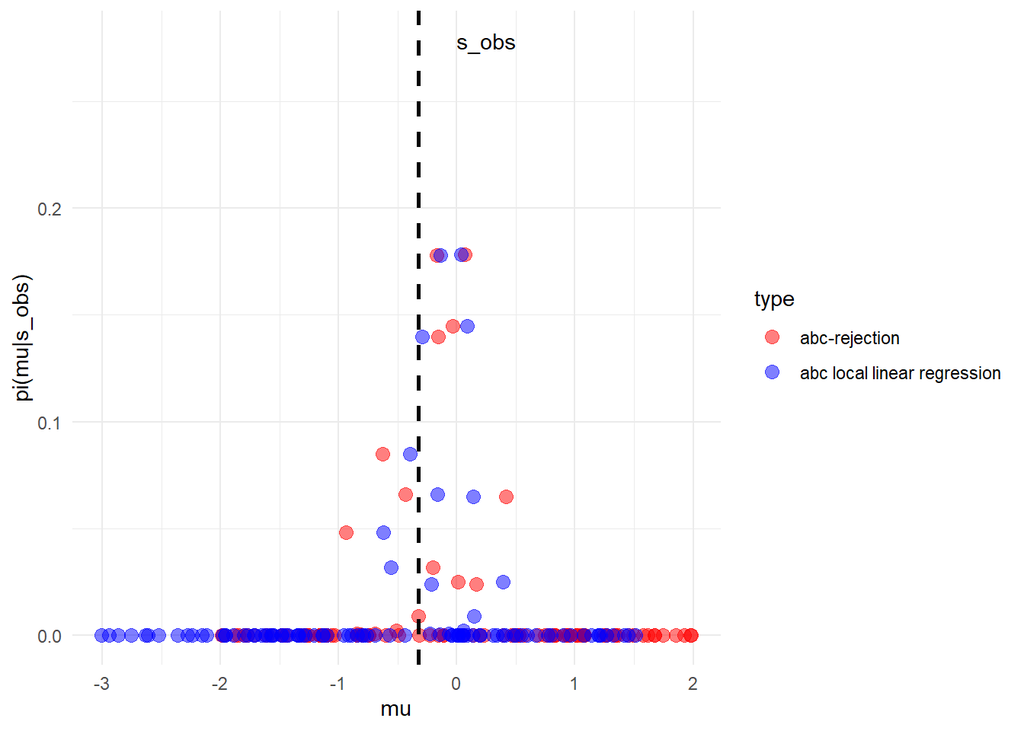

```r
corrected_mu <- abc_llr(c(s_obs), matrix(mu_vec), matrix(s_vec), weights3)
abc_df <- data.frame(
  x = c(mu_vec, corrected_mu),
  y = rep(weights3, 2),
  type = rep(c("abc-rejection", "abc local linear regression"),
               each = length(mu_vec))
)

ggplot(abc_df, aes(x = x, y = y, color = type)) +
geom_point(data=abc_df, size=3, alpha=0.5) +
scale_color_manual(values=c("red", "blue")) +
labs(x="mu", y="pi(mu|s_obs)") +
geom_vline(xintercept = s_obs, color = "black", linetype = "dashed", size = 1) +
annotate("text", x = 0, y = max(abc_df$y)+0.1, label = "s_obs", color = "black", hjust = 0) +
theme_minimal()
```

## ABC-MCMC

Then we generate parameter $\mu$ using ABC-MCMC method. The assumption
$$\begin{align}
\mu &\sim U[-2, 2]\\
Y_i &\sim \mathcal{N}(\mu, 1), \ \text{for }i = 1, \dots, 10,\\
\end{align}$$
is the proposal and prior distribution here. The code block generate 10001 $\mu$s and we drop the first 5000 samples and plot the histogram.

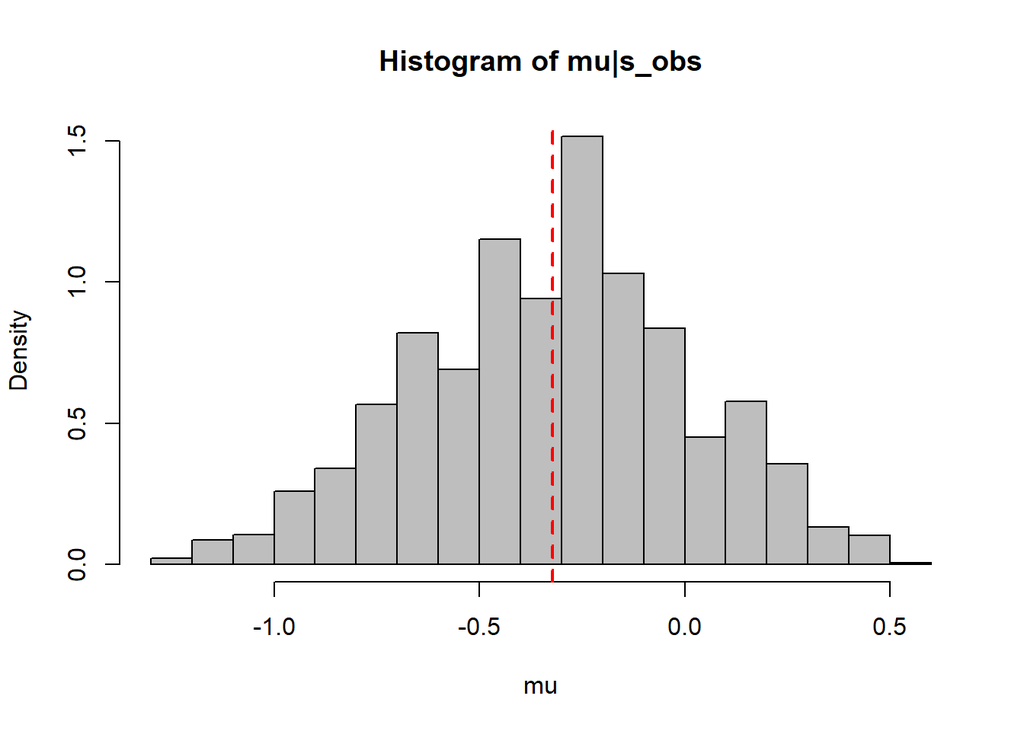

```r
# proposal function
p_theta <- function(theta_0) {
  runif(1, min=-2, max=2)
}
d_theta <- function(theta_1, theta_0) {
  if (theta_1 < 2 & theta_1 > -2) {return(log(1/4))}
  return(log(0))
}
# model sample
p_s <- function(theta) {
  mean(rnorm(10, mean=theta), sd=1)
}
# initial theta
mu_0 <- runif(1, min=-2, max=2)
# M-H
matrix_list <- abc_mcmc(c(s_obs), 0.01, gaussian_kernel, p_theta, d_theta, p_s, d_theta, mu_0, 10000)
# hist of posterior
hist(matrix_list$theta_matrix[5000:10001, ], probability = TRUE, main = "Histogram of mu|s_obs",
     breaks = 20, col = "gray", border = "black", xlab="mu")
abline(v = s_obs, col = "red", lwd = 2, lty = 2)
```

## ABC-PMC

The ABC-PMC method takes the same proposal and summary statistics with a tolerance sequence $(\epsilon_1, \dots, \epsilon_5) = (10, 2, 1.5, 1, 0.5)$. For each tolerance $\epsilon_i$, the algorithm samples 1000 $\mu$s. The histogram presents samples after the last iteration.

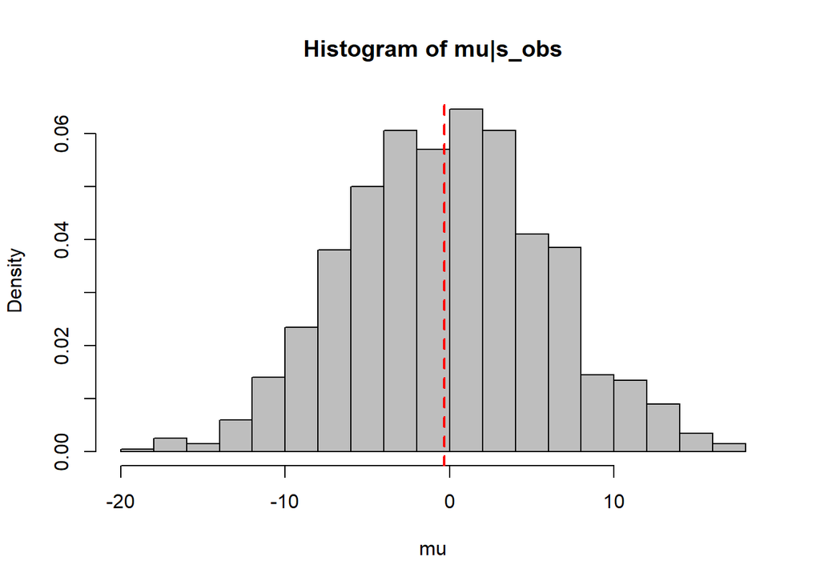

```r
# proposal function
p_theta <- function() {
  runif(1, min=-2, max=2)
}
d_theta <- function(theta) {
  if (theta < 2 & theta > -2) {return(log(1/4))}
  return(log(0))
}
# model sample
p_s <- function(theta) {
  mean(rnorm(10, mean=theta), sd=1)
}
# list of tolerance
tol <- c(10, 2, 1.5, 1, 0.5)
matrix_list <- abc_pmc(c(s_obs), tol, gaussian_kernel, p_theta, d_theta, p_s, 1000)
# hist of posterior
hist(matrix_list$theta_matrix, probability = TRUE, main = "Histogram of mu|s_obs",
     breaks = 20, col = "gray", border = "black", xlab="mu")
abline(v = s_obs, col = "red", lwd = 2, lty = 2)
```